# Biostat 200B Homework 7

Due Mar 8 @ 11:59PM

Author

Ziheng Zhang_606300061

## Question 1

**How do we interpret the parameter estimates in this output? Specifically, how do these parameter estimates relate to the group means?**

### Answer:

The SAS codes are as follows:

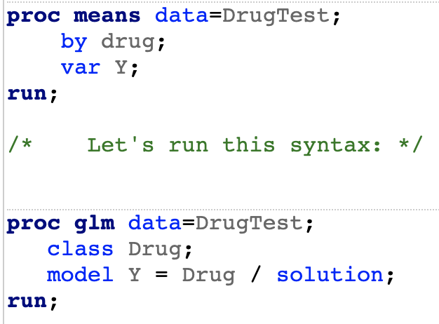

The parameter estimates and group means are as follows:

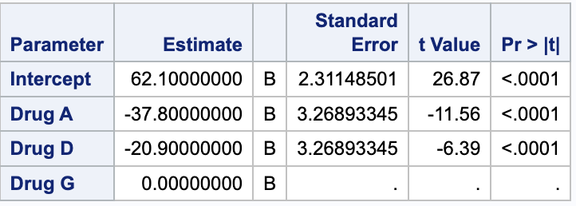

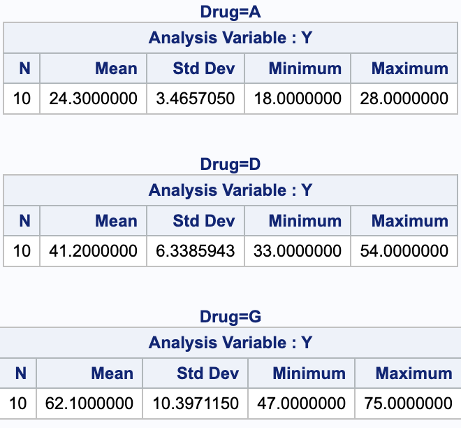

The parameter estimates in these outputs are the differences between the group estimated means and the reference group estimated mean. The reference group is the `Drug G` group.  
The parameter estimate for `Intercept` is $62.1$, which means the estimated mean of the response variable for the `Drug G` group is 62.1.  
The parameter estimate for the `Drug A` group is $-37.8$, which means the estimated mean of the response variable for the `Drug A` group is 37.8 lower than the estimated mean of the `Drug G` group. $\hat{\mu}_{\text{A}} - \hat{\mu}_{\text{G}} = 24.3 - 62.1 = -37.8$.  
The parameter estimate for the `Drug D` group is $-20.9$, which means the estimated mean of the response variable for the `Drug D` group is 20.9 lower than the estimated mean of the `Drug G` group. $\hat{\mu}_{\text{D}} - \hat{\mu}_{\text{G}} = 41.2 - 62.1 = -20.9$.  
The parameter estimate for the `Drug G` group is $0$, because the reference group is `Drug G`. $\hat{\mu}_{\text{G}} - \hat{\mu}_{\text{G}} = 62.1 - 62.1 = 0$. And this may be also because that this model will be overparameterized if we include the `Drug G` group in the model. So SAS will automatically drop the last group, the `Drug G` group.

## Question 2

**Where in the plots do you see evidence of violation of the homogeneity of variance assumption?**

### Answer:

The distribution of of `smell` for each age group is as follow:

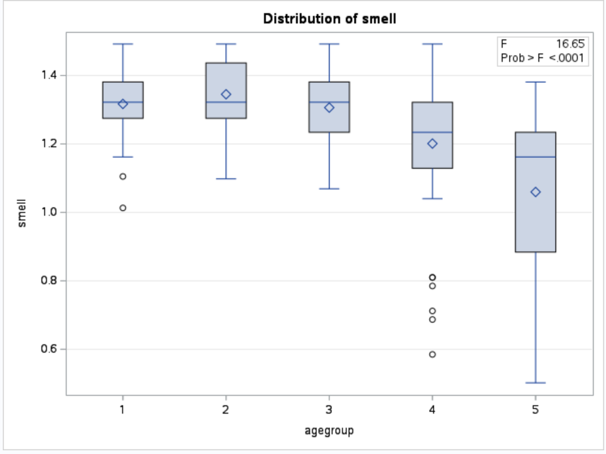

From the boxplots we can see that the variance of `smell` for the `oldest` group is much larger than the variance of `smell` for the other four age group because the length of the box is the variance of the `smell` for each age group and the length of the box for the `oldest` group is much larger than the length of the box for the other four age group. This is evidence of violation of the homogeneity of variance assumption.

The results for the Levene’s test for homogeneity of variance are as follows:

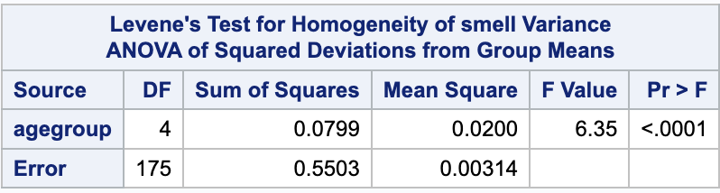

The F-test value is $6.35$ and the p-value is $<0.0001$, which means the variance of `smell` for the five age groups are not all equal to each other. This is evidence of violation of the homogeneity of variance assumption.

## Question 3

**Write code and estimate the pairwise contrasts between the youngest age group and each other age group. Use an appropriate method to control for multiple comparisons.**

### Answer:

The SAS codes are as follows:

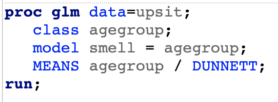

The estimated contrasts results are as follows:

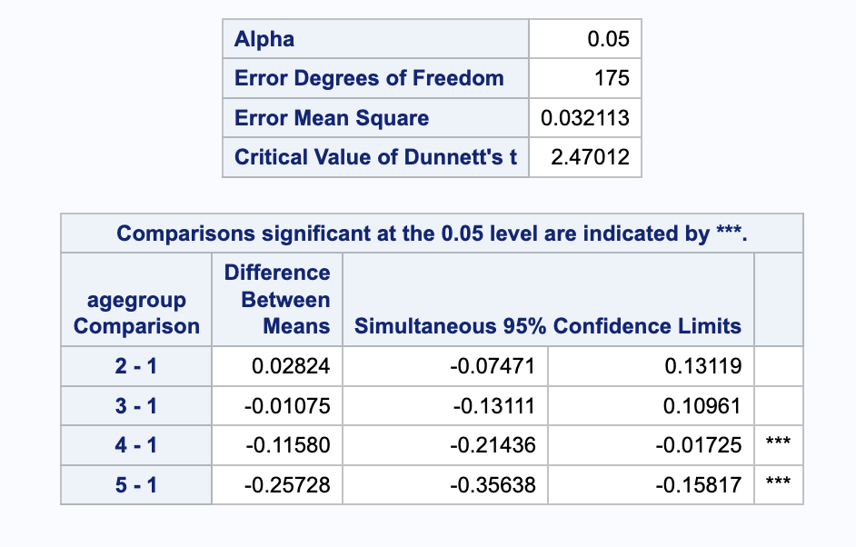

Dunnett’s method is to compare each treatment group to a single control group. From the results, we can see the $95\%$ confidence limits for the `Youngest vs. AGE Group 4` and the `Youngest vs. AGE Group 5` have only negative values and $0$ is not included in the confidence limits, which means the mean values of the sense of smell between the **youngest** age group and the **fourth** age group are significantly different, and the mean values of the sense of smell between the **youngest** age group and the **fifth** age group are significantly different.

The $95\%$ confidence limits for the `Youngest vs. AGE Group 2` and the `Youngest vs. AGE Group 3` have both positive and negative values and $0$ is included in the confidence limits, which means the mean values of the sense of smell between the **youngest** age group and the **second** age group are not significantly different, and the mean values of the sense of smell between the **youngest** age group and the **third** age group are not significantly different.

## Question 4

**Use orthogonal polynomial contrasts to test for a linear, quadratic and cubic trend. What do you conclude?**

### Answer:

The SAS codes are as follows:

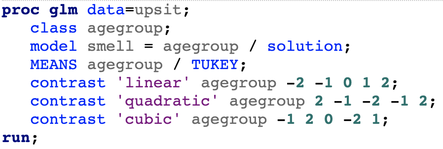

The results for the orthogonal polynomial contrasts are as follows:

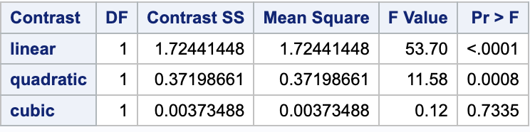

The F-test value for the linear trend is $53.70$ and the p-value is $<0.0001$, which means there is significant evidence that linear trend in the mean values of the sense of smell for the five age groups exists.  
The F-test value for the quadratic trend is $11.58$ and the p-value is $0.0008$, which means there is significant evidence that quadratic trend in the mean values of the sense of smell for the five age groups exists.  
The F-test value for the cubic trend is $0.12$ and the p-value is $0.7335$, which means there is no significant evidence that cubic trend in the mean values of the sense of smell for the five age groups exists.

## Question 5

**Remove the last (oldest) group so that there are now 4 age groups. Determine the appropriate orthogonal polynomial contrasts to test for a linear and quadratic trend with 4 groups. Test the contrasts. What do you conclude?**

### Answer:

The SAS codes are as follows:

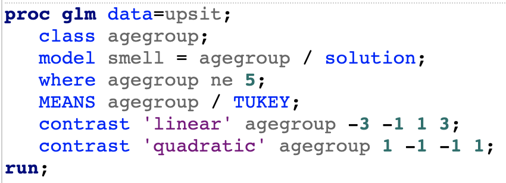

The results for the orthogonal polynomial contrasts are as follows:

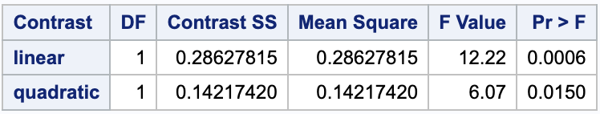

The F-test value for the linear trend is $12.22$ and the p-value is $0.0006$, which means after removing the last (oldest) group, there is still significant evidence that linear trend in the mean values of the sense of smell for the four age groups exists.  
The F-test value for the quadratic trend is $6.07$ and the p-value is $0.0150$, which means after removing the last (oldest) group, there is still significant evidence that quadratic trend in the mean values of the sense of smell for the four age groups exists.  
For linear and quadratic trends, both five age groups and four age groups have significant evidence, which means for the mean values of the sense of smell, the linear and quadratic trends are significant for all ages.

## Question 6

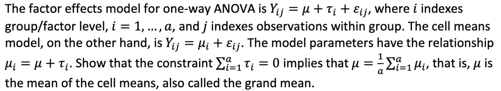

### Answer:

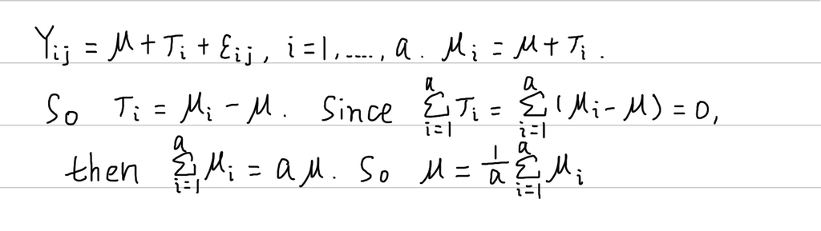

## Question 7

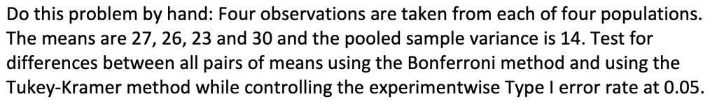

### Answer:

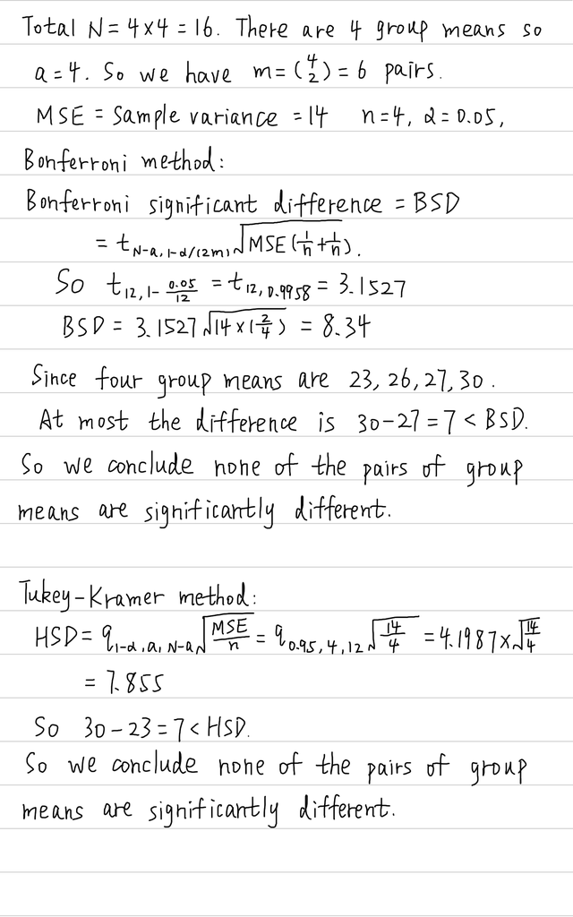